# Discussion 4

## Group 26 (use the assigned group name/number)

## Members Present

**Nico Salm**, Naman Sogani, Jeremy Emch, Dheeraj Pasikanti

## Data

You need the following datasets for this discussion (found on canvas).

- `atlanta-2018.tsv`
- `chicago-2018.csv`

Note the Atlanta file is a tsv file (tab separated values), which means the columns are separated by tabs, and needs to be read by the `read_tsv` command, which is included in the `readr` package.

Also note the Chicago csv file we are providing for this discussion is different than the ORD-2018 csv file we used in lecture. This file is separated by semicolons, which is the common format in Europe, so you need to use the European version of the read command `read_csv2` to read it in correctly.

Of course you can use `read_delim` instead of `read_tsv` and `read_csv2` if you specify the correct delimiter argument, but these specialized functions may be more convenient.

## Questions

### 1

Complete the chunk below to do the following:

1. Select only the `airport`, `date`, `all_total`, and `all_flights` columns,
2. Parse the `date` column into a date format,
3. Rename the `all_total` and `all_flights` columns as `passengers` and `flights`,
4. Compute total passengers and flights counts for each date at each airport,
5. Add columns `wday` and `month` to indicate the weekday and month each date corresponds to. Make sure to use `label=TRUE` to get a name output,
6. And finally, sort the data frame by date from earliest to latest.

```r
atlanta_data = read_tsv('../../data/atlanta-2018.tsv') %>%
  select(airport, date, all_total, all_flights) %>%
  mutate(date = dmy(date),
         passengers = all_total,
         flights = all_flights) %>%
  select(-all_total, -all_flights)

chicago_data = read_csv2('../../data/chicago-2018.csv') %>%
  select(airport, date, all_total, all_flights) %>%
  mutate(date = dmy(date),
         passengers = all_total,
         flights = all_flights) %>%
  select(-all_total, -all_flights)

# Combine data
all_data = bind_rows(atlanta_data, chicago_data)

# Compute totals and add wday and month
final_data = all_data %>%
  group_by(airport, date) %>%
  summarise(passengers = sum(passengers),
            flights = sum(flights)) %>%
  ungroup() %>%
  mutate(wday = wday(date, label = TRUE),
         month = month(date, label = TRUE)) %>%
  arrange(date)
```

### 2

Now, do the following:

- Create a summary data frame named `atl_sum` with columns for the average number of international flight arrivals per day and the average number of daily passengers arriving on international flights per day in Atlanta by day of the week.
- This data frame will have three columns, one for day of the week, and one for each of the two quantitative variables.
- Print out the summary data frame in a table with the rows arranged in order by days of the week from Sunday through Saturday.
- Also, print out the summary data frame in a table with the rows arranged in order from most to least average number of international flight arrivals.

*Note: You should have two summary data frames print, each arranged in a different order according to the directions above.*

```r
# Filter for Atlanta's data
atl_data = final_data %>%
  filter(airport == "ATL") %>%
  filter(!is.na(wday)) # otherwise we have a NA row

# Group by day of the week and summarize
atl_sum = atl_data %>%
  group_by(wday) %>%
  summarise(average_flights = mean(flights, na.rm = TRUE),
            average_passengers = mean(passengers, na.rm = TRUE))

# Print summary arranged by days of the week
atl_sum_ordered_by_day = atl_sum %>%
  arrange(match(wday, c("Sun", "Mon", "Tue", "Wed", "Thu", "Fri", "Sat")))
atl_sum_ordered_by_day
```

```
## # A tibble: 7 × 3
##   wday  average_flights average_passengers
##   <ord>           <dbl>              <dbl>
## 1 Sun              88.8             15552.
## 2 Mon              83.0             14142.
## 3 Tue              88.2             15302.
## 4 Wed              87.7             15090.
## 5 Thu              89.6             15559.
## 6 Fri              86.6             15128.
## 7 Sat              88.4             15242.
```

```r
# Print summary arranged by most to least average number of international flight arrivals
atl_sum_ordered_by_flights = atl_sum %>%
  arrange(desc(average_flights))
atl_sum_ordered_by_flights
```

```
## # A tibble: 7 × 3
##   wday  average_flights average_passengers
##   <ord>           <dbl>              <dbl>
## 1 Thu              89.6             15559.
## 2 Sun              88.8             15552.
## 3 Sat              88.4             15242.
## 4 Tue              88.2             15302.
## 5 Wed              87.7             15090.
## 6 Fri              86.6             15128.
## 7 Mon              83.0             14142.
```

### 3

> On what single date in April of 2018 did the largest number of international passengers arrive at the Atlanta airport? How many passengers were there? What day of the week was this date? Sunday, 21758 passengers.

```r
final_data %>%
  filter(airport == "ATL" &
         month(date) == 4 &
         year(date) == 2018) %>%
  arrange(desc(passengers)) %>%
  slice(1)  # Select the topmost row
```

```
## # A tibble: 1 × 6
##   airport date       passengers flights wday  month
##   <chr>   <date>          <dbl>   <dbl> <ord> <ord>
## 1 ATL     2018-04-08      21758     116 Sun   Apr
```

### 4

```r
chicago_data_hourly = read_csv2('../../data/chicago-2018.csv')

chicago_data_daily = chicago_data_hourly %>%
  mutate(date = dmy(date),  # Parse the date
         hour_start = as.numeric(substr(hour, 1, 2)), # Extract the start hour
         datetime = date + hours(hour_start)) %>%  # Combine date with hour to get a datetime column
  group_by(airport, date) %>%
  summarise(passengers = sum(all_total, na.rm = TRUE),
            flights = sum(all_flights, na.rm = TRUE)) %>%
  ungroup()
```

### 5

> Using the Chicago data, make a line plot that shows the total number of international flights arriving to the airport by month. (Note: add `group = 1` as an aesthetic so that there is a single line for all months.)

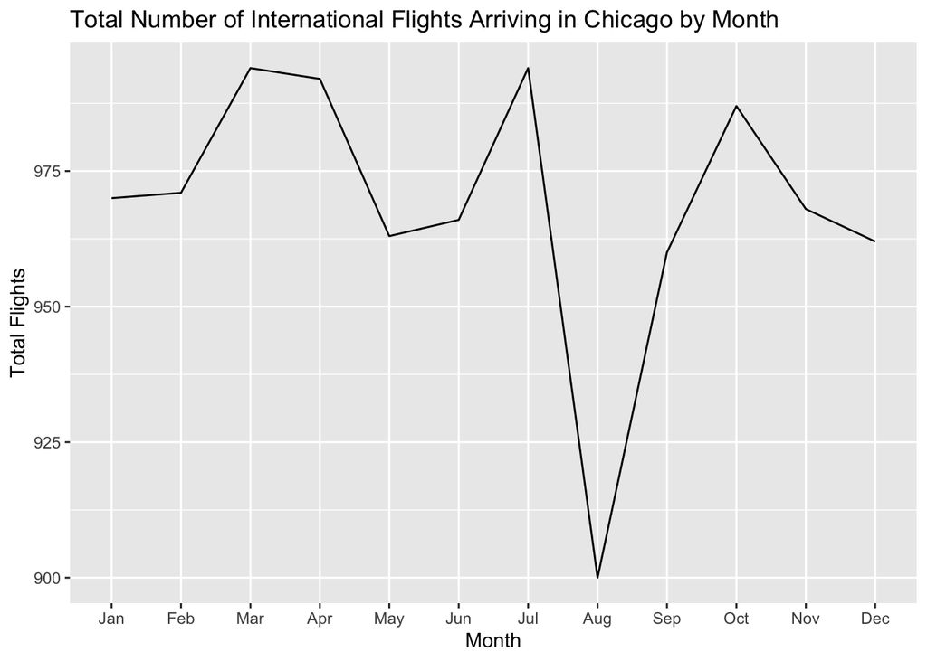

```r
monthly_flights = chicago_data_daily %>%
  filter(!is.na(date)) %>%
  group_by(month = month(date, label = TRUE)) %>%
  summarise(total_flights = sum(flights)) %>%
  arrange(month)

ggplot(monthly_flights, aes(month, total_flights, group = 1)) +
  geom_line() +
  labs(title = "Total Number of International Flights Arriving in Chicago by Month",
       x = "Month",
       y = "Total Flights")
```